# Risk Factor Analysis

## Outcome Variable

**Outcome Variable:** co_occurence

## Predictor Variables

**Intervention Variable:** ever_underweight06

**Adjustment Set:**

- sex
- arm
- brthmon
- single
- hhwealth_quart
- W_mage
- W_mhtcm
- W_meducyrs
- W_feducyrs
- delta_brthmon
- delta_single
- delta_hhwealth_quart
- delta_W_mage
- delta_W_mhtcm
- delta_W_meducyrs
- delta_W_feducyrs

## Stratifying Variables

The analysis was stratified on these variable(s):

- studyid
- country

## Data Summary

| studyid | country | ever_underweight06 | co_occurence | n_cell | n |
| --- | --- | --- | --- | --- | --- |
| CMC-V-BCS-2002 | INDIA | 0 | 0 | 188 | 369 |
| CMC-V-BCS-2002 | INDIA | 0 | 1 | 1 | 369 |
| CMC-V-BCS-2002 | INDIA | 1 | 0 | 159 | 369 |
| CMC-V-BCS-2002 | INDIA | 1 | 1 | 21 | 369 |
| CMIN | BANGLADESH | 0 | 0 | 109 | 237 |
| CMIN | BANGLADESH | 0 | 1 | 2 | 237 |
| CMIN | BANGLADESH | 1 | 0 | 102 | 237 |
| CMIN | BANGLADESH | 1 | 1 | 24 | 237 |
| COHORTS | GUATEMALA | 0 | 0 | 554 | 779 |
| COHORTS | GUATEMALA | 0 | 1 | 11 | 779 |
| COHORTS | GUATEMALA | 1 | 0 | 187 | 779 |
| COHORTS | GUATEMALA | 1 | 1 | 27 | 779 |
| COHORTS | PHILIPPINES | 0 | 0 | 1871 | 2487 |
| COHORTS | PHILIPPINES | 0 | 1 | 77 | 2487 |
| COHORTS | PHILIPPINES | 1 | 0 | 429 | 2487 |
| COHORTS | PHILIPPINES | 1 | 1 | 110 | 2487 |
| CONTENT | PERU | 0 | 0 | 192 | 200 |
| CONTENT | PERU | 0 | 1 | 0 | 200 |
| CONTENT | PERU | 1 | 0 | 8 | 200 |
| CONTENT | PERU | 1 | 1 | 0 | 200 |
| EE | PAKISTAN | 0 | 0 | 94 | 346 |
| EE | PAKISTAN | 0 | 1 | 4 | 346 |
| EE | PAKISTAN | 1 | 0 | 178 | 346 |
| EE | PAKISTAN | 1 | 1 | 70 | 346 |
| GMS-Nepal | NEPAL | 0 | 0 | 283 | 550 |
| GMS-Nepal | NEPAL | 0 | 1 | 12 | 550 |
| GMS-Nepal | NEPAL | 1 | 0 | 207 | 550 |
| GMS-Nepal | NEPAL | 1 | 1 | 48 | 550 |
| IRC | INDIA | 0 | 0 | 209 | 405 |
| IRC | INDIA | 0 | 1 | 2 | 405 |

[output cut: 78 more lines]

The following strata were considered:

- studyid: CMC-V-BCS-2002, country: INDIA
- studyid: CMIN, country: BANGLADESH
- studyid: COHORTS, country: GUATEMALA
- studyid: COHORTS, country: PHILIPPINES
- studyid: CONTENT, country: PERU
- studyid: EE, country: PAKISTAN
- studyid: GMS-Nepal, country: NEPAL
- studyid: IRC, country: INDIA
- studyid: JiVitA-4, country: BANGLADESH
- studyid: Keneba, country: GAMBIA
- studyid: LCNI-5, country: MALAWI
- studyid: MAL-ED, country: BANGLADESH
- studyid: MAL-ED, country: BRAZIL
- studyid: MAL-ED, country: INDIA
- studyid: MAL-ED, country: NEPAL
- studyid: MAL-ED, country: PERU
- studyid: MAL-ED, country: SOUTH AFRICA
- studyid: MAL-ED, country: TANZANIA, UNITED REPUBLIC OF
- studyid: NIH-Birth, country: BANGLADESH
- studyid: NIH-Crypto, country: BANGLADESH
- studyid: PROBIT, country: BELARUS
- studyid: PROVIDE, country: BANGLADESH
- studyid: ResPak, country: PAKISTAN
- studyid: SAS-CompFeed, country: INDIA
- studyid: SAS-FoodSuppl, country: INDIA
- studyid: TanzaniaChild2, country: TANZANIA, UNITED REPUBLIC OF
- studyid: ZVITAMBO, country: ZIMBABWE

### Dropped Strata

Some strata were dropped due to rare outcomes:

- studyid: CMC-V-BCS-2002, country: INDIA
- studyid: CMIN, country: BANGLADESH
- studyid: CONTENT, country: PERU
- studyid: EE, country: PAKISTAN
- studyid: IRC, country: INDIA
- studyid: MAL-ED, country: BANGLADESH
- studyid: MAL-ED, country: BRAZIL
- studyid: MAL-ED, country: INDIA
- studyid: MAL-ED, country: NEPAL
- studyid: MAL-ED, country: PERU
- studyid: MAL-ED, country: SOUTH AFRICA
- studyid: MAL-ED, country: TANZANIA, UNITED REPUBLIC OF
- studyid: PROBIT, country: BELARUS
- studyid: ResPak, country: PAKISTAN

## Methods Detail

We’re interested in the causal parameters $E[Y_a]$ for all values of $a \in \mathcal{A}$. These parameters represent the mean outcome if, possibly contrary to fact, we intervened to set all units to have $A=a$. Under the randomization and positivity assumptions, these are identified by the statistical parameters $\psi_a=E_W[E_{Y|A,W}(Y|A=a,W)]$. In addition, we’re interested in the mean of $Y$, $E[Y]$ under no intervention (the observed mean). We will estimate these parameters by using SuperLearner to fit the relevant likelihood factors – $E_{Y|A,W}(Y|A=a,W)$ and $p(A=a|W)$, and then updating our likelihood fit using a joint TMLE.

For unadjusted analyses ($W=\{\}$), initial likelihoods were estimated using Lrnr_glm to estimate the simple $E(Y|A)$ and Lrnr_mean to estimate $p(A)$. For adjusted analyses, a small library containing Lrnr_glmnet, Lrnr_xgboost, and Lrnr_mean was used.

Having estimated these parameters, we will then use the delta method to estimate relative risks and attributable risks relative to a prespecified baseline level of $A$.

# Results Detail

## Results Plots

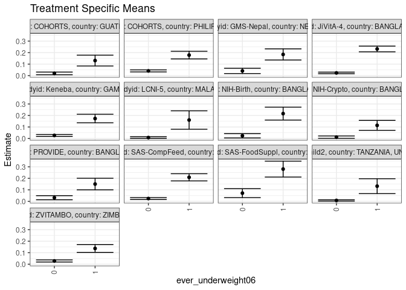

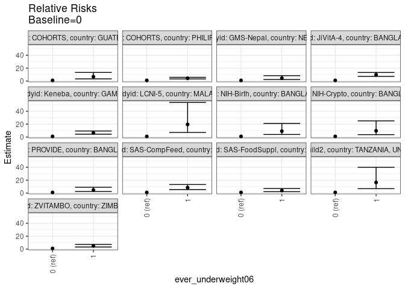

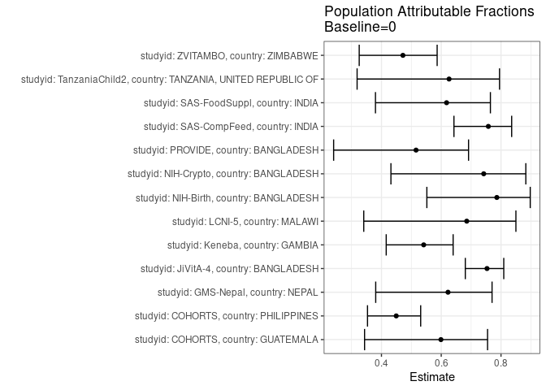

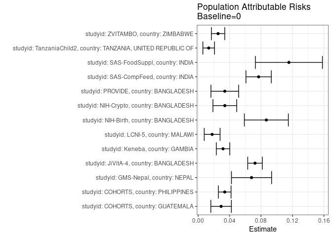

## Results Table

### Parameter: TSM

| studyid | country | intervention_level | baseline_level | estimate | ci_lower | ci_upper |
| --- | --- | --- | --- | --- | --- | --- |
| COHORTS | GUATEMALA | 0 | NA | 0.0195624 | 0.0080666 | 0.0310582 |
| COHORTS | GUATEMALA | 1 | NA | 0.1309943 | 0.0839853 | 0.1780034 |
| COHORTS | PHILIPPINES | 0 | NA | 0.0413993 | 0.0325609 | 0.0502377 |
| COHORTS | PHILIPPINES | 1 | NA | 0.1784981 | 0.1452148 | 0.2117815 |
| GMS-Nepal | NEPAL | 0 | NA | 0.0411646 | 0.0181657 | 0.0641635 |
| GMS-Nepal | NEPAL | 1 | NA | 0.1842203 | 0.1357937 | 0.2326468 |
| JiVitA-4 | BANGLADESH | 0 | NA | 0.0237232 | 0.0169244 | 0.0305219 |
| JiVitA-4 | BANGLADESH | 1 | NA | 0.2318300 | 0.2069507 | 0.2567093 |
| Keneba | GAMBIA | 0 | NA | 0.0268364 | 0.0186062 | 0.0350666 |
| Keneba | GAMBIA | 1 | NA | 0.1734412 | 0.1362493 | 0.2106332 |
| LCNI-5 | MALAWI | 0 | NA | 0.0081833 | 0.0010347 | 0.0153319 |
| LCNI-5 | MALAWI | 1 | NA | 0.1604938 | 0.0804992 | 0.2404884 |
| NIH-Birth | BANGLADESH | 0 | NA | 0.0236220 | 0.0049252 | 0.0423189 |
| NIH-Birth | BANGLADESH | 1 | NA | 0.2163462 | 0.1603287 | 0.2723636 |
| NIH-Crypto | BANGLADESH | 0 | NA | 0.0117925 | 0.0015091 | 0.0220758 |
| NIH-Crypto | BANGLADESH | 1 | NA | 0.1142857 | 0.0712208 | 0.1573507 |
| PROVIDE | BANGLADESH | 0 | NA | 0.0318269 | 0.0141914 | 0.0494624 |
| PROVIDE | BANGLADESH | 1 | NA | 0.1502680 | 0.0998266 | 0.2007094 |
| SAS-CompFeed | INDIA | 0 | NA | 0.0246193 | 0.0163121 | 0.0329265 |
| SAS-CompFeed | INDIA | 1 | NA | 0.2089937 | 0.1776198 | 0.2403676 |
| SAS-FoodSuppl | INDIA | 0 | NA | 0.0714184 | 0.0325853 | 0.1102516 |
| SAS-FoodSuppl | INDIA | 1 | NA | 0.2803600 | 0.2113183 | 0.3494018 |
| TanzaniaChild2 | TANZANIA, UNITED REPUBLIC OF | 0 | NA | 0.0080092 | 0.0020968 | 0.0139215 |
| TanzaniaChild2 | TANZANIA, UNITED REPUBLIC OF | 1 | NA | 0.1320755 | 0.0675890 | 0.1965620 |
| ZVITAMBO | ZIMBABWE | 0 | NA | 0.0284083 | 0.0193269 | 0.0374897 |
| ZVITAMBO | ZIMBABWE | 1 | NA | 0.1369874 | 0.1028766 | 0.1710982 |

### Parameter: E(Y)

| studyid | country | intervention_level | baseline_level | estimate | ci_lower | ci_upper |
| --- | --- | --- | --- | --- | --- | --- |
| COHORTS | GUATEMALA | NA | NA | 0.0487805 | 0.0336441 | 0.0639169 |
| COHORTS | PHILIPPINES | NA | NA | 0.0751910 | 0.0648251 | 0.0855569 |
| GMS-Nepal | NEPAL | NA | NA | 0.1090909 | 0.0830130 | 0.1351688 |
| JiVitA-4 | BANGLADESH | NA | NA | 0.0961073 | 0.0860713 | 0.1061434 |
| Keneba | GAMBIA | NA | NA | 0.0585078 | 0.0478474 | 0.0691682 |
| LCNI-5 | MALAWI | NA | NA | 0.0260116 | 0.0141438 | 0.0378793 |
| NIH-Birth | BANGLADESH | NA | NA | 0.1103896 | 0.0817833 | 0.1389959 |
| NIH-Crypto | BANGLADESH | NA | NA | 0.0457413 | 0.0294659 | 0.0620168 |
| PROVIDE | BANGLADESH | NA | NA | 0.0657194 | 0.0452330 | 0.0862057 |
| SAS-CompFeed | INDIA | NA | NA | 0.1015873 | 0.0902183 | 0.1129563 |
| SAS-FoodSuppl | INDIA | NA | NA | 0.1869159 | 0.1442025 | 0.2296293 |
| TanzaniaChild2 | TANZANIA, UNITED REPUBLIC OF | NA | NA | 0.0214286 | 0.0123577 | 0.0304995 |
| ZVITAMBO | ZIMBABWE | NA | NA | 0.0537825 | 0.0430304 | 0.0645346 |

### Parameter: RR

| studyid | country | intervention_level | baseline_level | estimate | ci_lower | ci_upper |
| --- | --- | --- | --- | --- | --- | --- |
| COHORTS | GUATEMALA | 0 | 0 | 1.000000 | 1.000000 | 1.000000 |
| COHORTS | GUATEMALA | 1 | 0 | 6.696220 | 3.358709 | 13.350176 |
| COHORTS | PHILIPPINES | 0 | 0 | 1.000000 | 1.000000 | 1.000000 |
| COHORTS | PHILIPPINES | 1 | 0 | 4.311620 | 3.248990 | 5.721800 |
| GMS-Nepal | NEPAL | 0 | 0 | 1.000000 | 1.000000 | 1.000000 |
| GMS-Nepal | NEPAL | 1 | 0 | 4.475208 | 2.414169 | 8.295813 |
| JiVitA-4 | BANGLADESH | 0 | 0 | 1.000000 | 1.000000 | 1.000000 |
| JiVitA-4 | BANGLADESH | 1 | 0 | 9.772302 | 7.191892 | 13.278547 |
| Keneba | GAMBIA | 0 | 0 | 1.000000 | 1.000000 | 1.000000 |
| Keneba | GAMBIA | 1 | 0 | 6.462906 | 4.451024 | 9.384168 |
| LCNI-5 | MALAWI | 0 | 0 | 1.000000 | 1.000000 | 1.000000 |
| LCNI-5 | MALAWI | 1 | 0 | 19.612346 | 7.173595 | 53.619435 |
| NIH-Birth | BANGLADESH | 0 | 0 | 1.000000 | 1.000000 | 1.000000 |
| NIH-Birth | BANGLADESH | 1 | 0 | 9.158654 | 3.982549 | 21.062122 |
| NIH-Crypto | BANGLADESH | 0 | 0 | 1.000000 | 1.000000 | 1.000000 |
| NIH-Crypto | BANGLADESH | 1 | 0 | 9.691429 | 3.748225 | 25.058208 |
| PROVIDE | BANGLADESH | 0 | 0 | 1.000000 | 1.000000 | 1.000000 |
| PROVIDE | BANGLADESH | 1 | 0 | 4.721416 | 2.473616 | 9.011815 |
| SAS-CompFeed | INDIA | 0 | 0 | 1.000000 | 1.000000 | 1.000000 |
| SAS-CompFeed | INDIA | 1 | 0 | 8.489023 | 5.423345 | 13.287649 |
| SAS-FoodSuppl | INDIA | 0 | 0 | 1.000000 | 1.000000 | 1.000000 |
| SAS-FoodSuppl | INDIA | 1 | 0 | 3.925597 | 2.174275 | 7.087561 |
| TanzaniaChild2 | TANZANIA, UNITED REPUBLIC OF | 0 | 0 | 1.000000 | 1.000000 | 1.000000 |
| TanzaniaChild2 | TANZANIA, UNITED REPUBLIC OF | 1 | 0 | 16.490566 | 6.805473 | 39.958836 |
| ZVITAMBO | ZIMBABWE | 0 | 0 | 1.000000 | 1.000000 | 1.000000 |
| ZVITAMBO | ZIMBABWE | 1 | 0 | 4.822091 | 3.214215 | 7.234288 |

### Parameter: PAR

| studyid | country | intervention_level | baseline_level | estimate | ci_lower | ci_upper |
| --- | --- | --- | --- | --- | --- | --- |
| COHORTS | GUATEMALA | 0 | NA | 0.0292181 | 0.0161151 | 0.0423210 |
| COHORTS | PHILIPPINES | 0 | NA | 0.0337917 | 0.0257248 | 0.0418585 |
| GMS-Nepal | NEPAL | 0 | NA | 0.0679263 | 0.0423845 | 0.0934680 |
| JiVitA-4 | BANGLADESH | 0 | NA | 0.0723841 | 0.0630905 | 0.0816778 |
| Keneba | GAMBIA | 0 | NA | 0.0316714 | 0.0231087 | 0.0402341 |
| LCNI-5 | MALAWI | 0 | NA | 0.0178283 | 0.0077434 | 0.0279131 |
| NIH-Birth | BANGLADESH | 0 | NA | 0.0867676 | 0.0587762 | 0.1147589 |
| NIH-Crypto | BANGLADESH | 0 | NA | 0.0339489 | 0.0188096 | 0.0490881 |
| PROVIDE | BANGLADESH | 0 | NA | 0.0338925 | 0.0162834 | 0.0515016 |
| SAS-CompFeed | INDIA | 0 | NA | 0.0769680 | 0.0608435 | 0.0930925 |
| SAS-FoodSuppl | INDIA | 0 | NA | 0.1154974 | 0.0728673 | 0.1581275 |
| TanzaniaChild2 | TANZANIA, UNITED REPUBLIC OF | 0 | NA | 0.0134194 | 0.0060109 | 0.0208280 |
| ZVITAMBO | ZIMBABWE | 0 | NA | 0.0253742 | 0.0168807 | 0.0338677 |

### Parameter: PAF

| studyid | country | intervention_level | baseline_level | estimate | ci_lower | ci_upper |
| --- | --- | --- | --- | --- | --- | --- |
| COHORTS | GUATEMALA | 0 | NA | 0.5989702 | 0.3434918 | 0.7550298 |
| COHORTS | PHILIPPINES | 0 | NA | 0.4494112 | 0.3533231 | 0.5312218 |
| GMS-Nepal | NEPAL | 0 | NA | 0.6226576 | 0.3807710 | 0.7700572 |
| JiVitA-4 | BANGLADESH | 0 | NA | 0.7531595 | 0.6805632 | 0.8092574 |
| Keneba | GAMBIA | 0 | NA | 0.5413189 | 0.4158978 | 0.6398090 |
| LCNI-5 | MALAWI | 0 | NA | 0.6853973 | 0.3407366 | 0.8498706 |
| NIH-Birth | BANGLADESH | 0 | NA | 0.7860120 | 0.5519125 | 0.8978082 |
| NIH-Crypto | BANGLADESH | 0 | NA | 0.7421926 | 0.4316899 | 0.8830486 |
| PROVIDE | BANGLADESH | 0 | NA | 0.5157152 | 0.2399751 | 0.6914156 |
| SAS-CompFeed | INDIA | 0 | NA | 0.7576538 | 0.6425351 | 0.8356995 |
| SAS-FoodSuppl | INDIA | 0 | NA | 0.6179113 | 0.3799648 | 0.7645428 |
| TanzaniaChild2 | TANZANIA, UNITED REPUBLIC OF | 0 | NA | 0.6262395 | 0.3184894 | 0.7950187 |
| ZVITAMBO | ZIMBABWE | 0 | NA | 0.4717929 | 0.3255574 | 0.5863210 |